# San Francisco Crime Analysis

Seth Hodgkins

12/16/2020

# Introduction

```
# About the Dataset
```

The San Francisco Crime Dataset contains over 850,000 reports spanning nearly 12 years. The reports detail when and where the crime occurred, the type of crime, and the resolution.

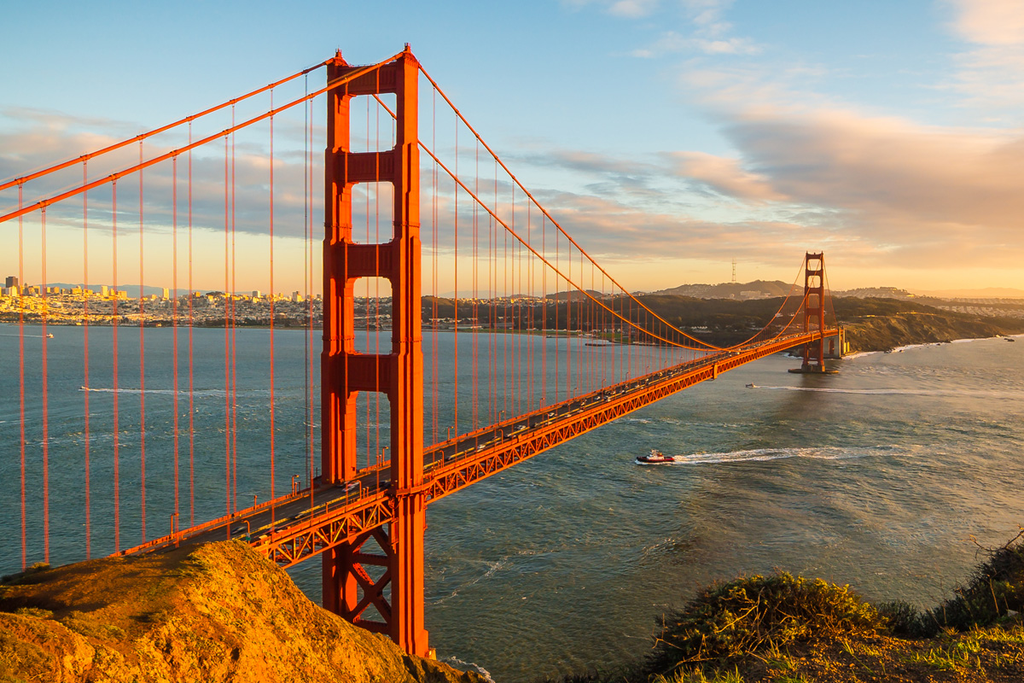

# Exploring the Data

Originally I had a smaller version of the dataset I have now, with 150,500 reports all from 2016.

```
# Tables
```

I first asked as many questions as I could, and learned about them through tables

- Questions like…
  - most common crimes
  - day of the weeks effect on crime
  - day of the months effect on crime
  - which criminals are hardest to catch
  - the most common type of crime
  - crimes by district

# Visualization

I then went on to visualize the tables I found intriguing

```
# Spacial Data
```

There were lots of questions that involved spacial data, so I needed to learn how to use maps. The hardest part was downloading and configuring the map, actually plotting data was easy!

Every crime report has a latitude and longitude, allowing you to visualize just about anything on a map.

- A couple visualizations I tried were
  - Crimes by District
  - Thefts in January

# Visualization

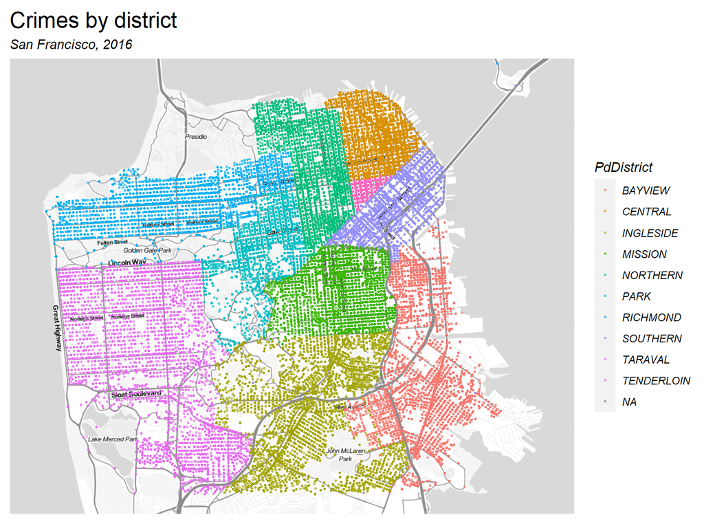

# Visualization

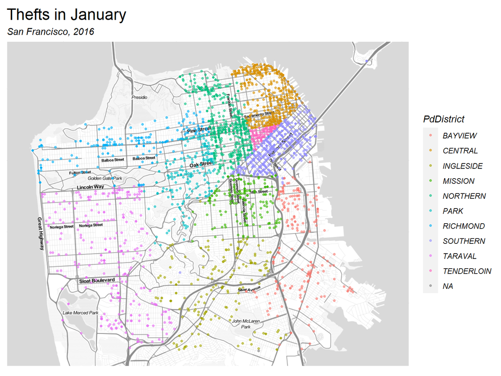

# Visualization

```
# Non-Spacial Data
```

Next, I tried visualizing some non-spatial data like

- Category vs Resolution
- word cloud of `OTHER OFFENSES` descriptions
  - One of the largest values in Category is `OTHER OFFENSES`, which isn’t very descriptive

# Visualization

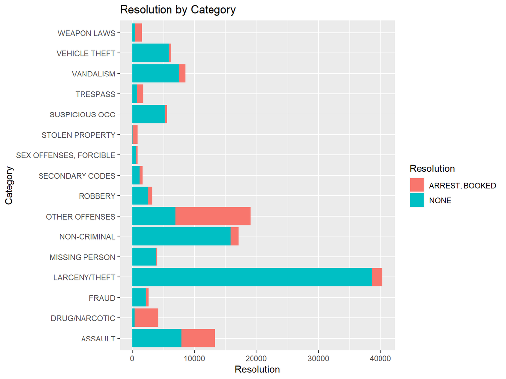

# Visualization

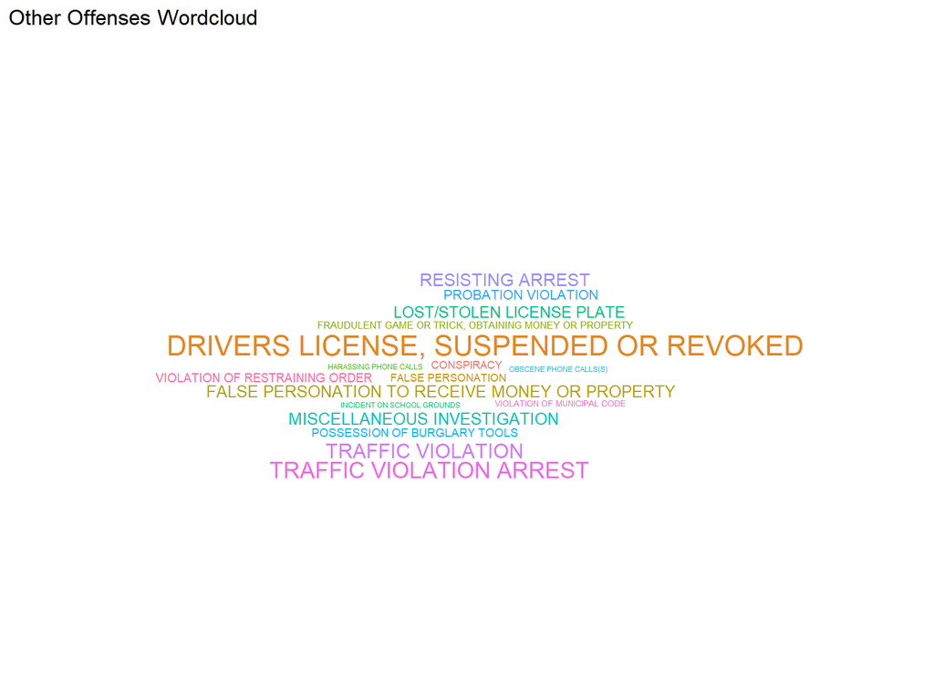

# Visualization

```
Importing datasets
```

I soon realized there was not enough variables to make a lot of interesting visuals, so I started importing relevant datasets I found online. I also noticed a much larger version of my dataset, the one with over 850,000 reports spanning 12 years.

- I imported…
  - Population data for each district
  - Income data for each district
  - Five years of weather data

```
Putting it to Use
```

I’ll show you a couple visualizations I made with the new data

- Income by District vs Crime
- Temperature vs Crime

I couldn’t find a dataset for population or income in each district so I looked up all the districts individually

```r
popDistrict <- tibble(PdDistrict = c("BAYVIEW", "CENTRAL", "INGLESIDE", "MISSION", "NORTHERN", "PARK", "RICHMOND", "SOUTHERN", "TARAVAL", "TENDERLOIN"), Population = c(35363, 76663, 85166, 7291, NA, 29399, 43795, 39198, 163000, 9334), Income = c(84542, 144349, 115728, 161731, NA, 150980, 163708, 144394, 169947, 95281))
popDistrict
```

```
## # A tibble: 10 x 3
##    PdDistrict Population Income
##    <chr>           <dbl>  <dbl>
##  1 BAYVIEW         35363  84542
##  2 CENTRAL         76663 144349
##  3 INGLESIDE       85166 115728
##  4 MISSION          7291 161731
##  5 NORTHERN           NA     NA
##  6 PARK            29399 150980
##  7 RICHMOND        43795 163708
##  8 SOUTHERN        39198 144394
##  9 TARAVAL        163000 169947
## 10 TENDERLOIN       9334  95281
```

# Visualizations

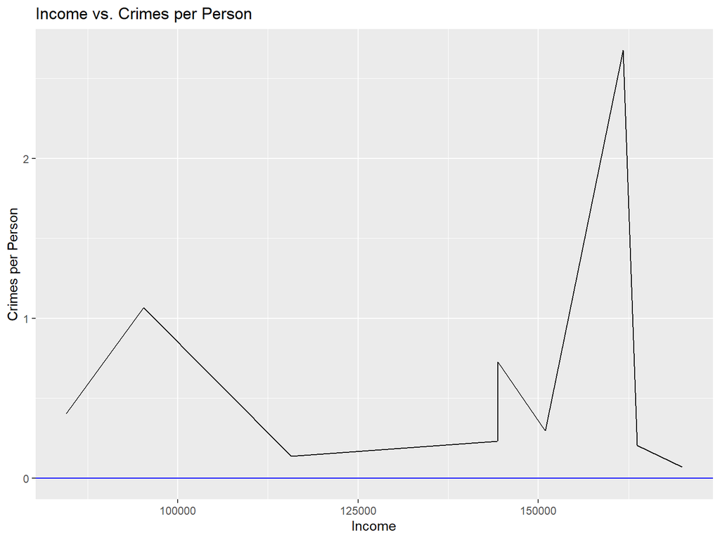

# Visualizations

```
## (Intercept)     AvgTemp
##  378.257837    2.609722
```

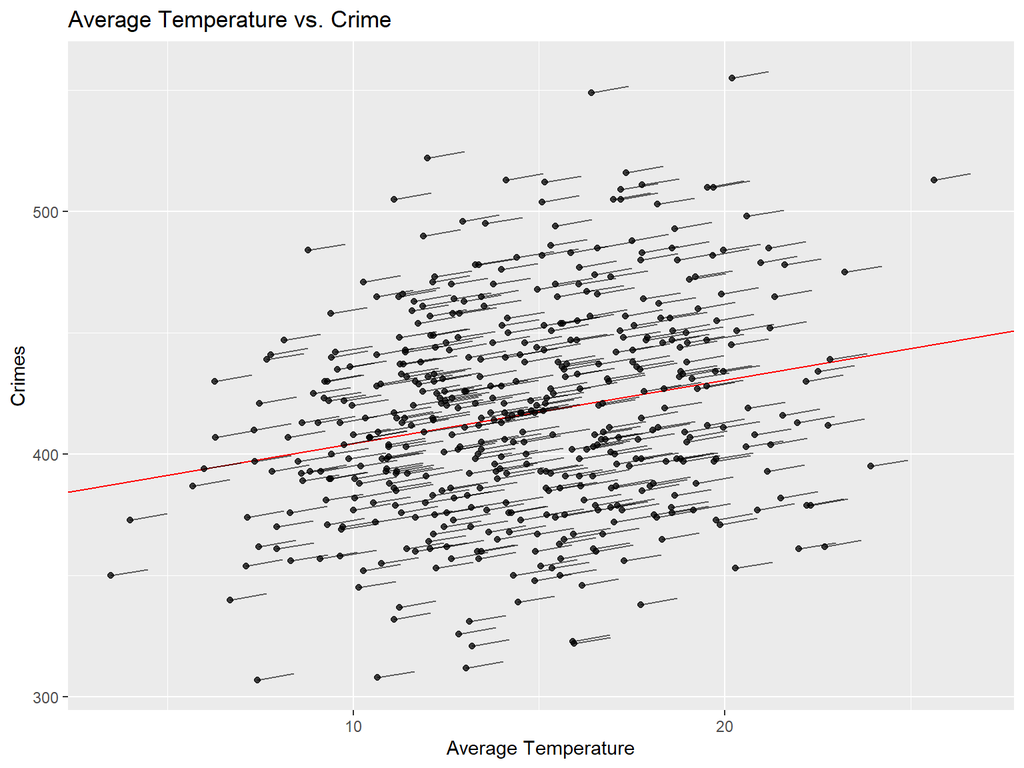

# Modeling

Finally, I moved onto the modeling stage where I struggled quite a bit. The first thing I tried to do was create a model that would show me how the rate of crime has fluctuated over the years.

```
# Date vs Crime
```

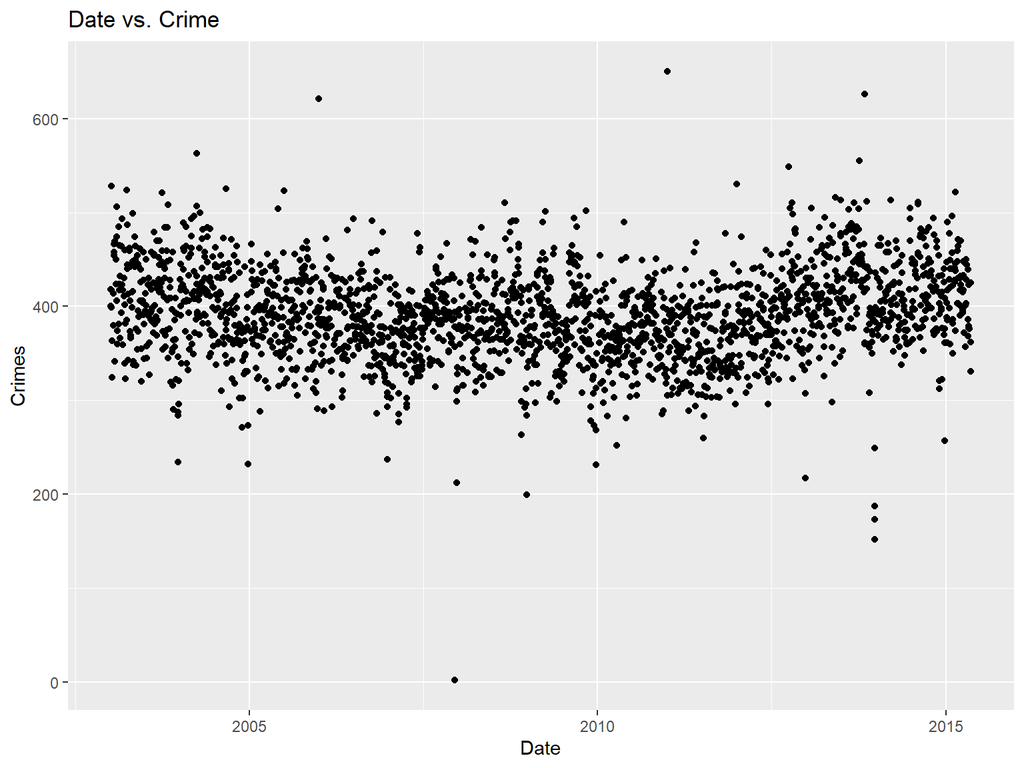

# Modeling

I thought most of the spikes were due to crime patterns in the days of the week, days of the month, months of the year, and days of the year. I visualized each and then used models of them to try to get a better relationship between date and crime.

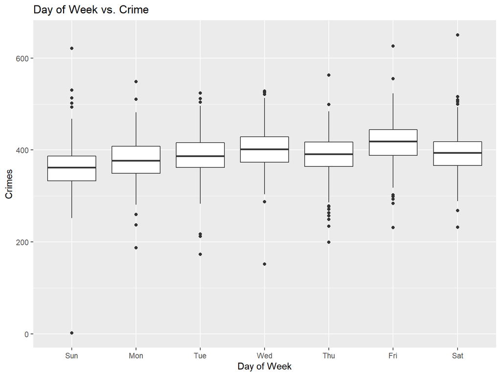

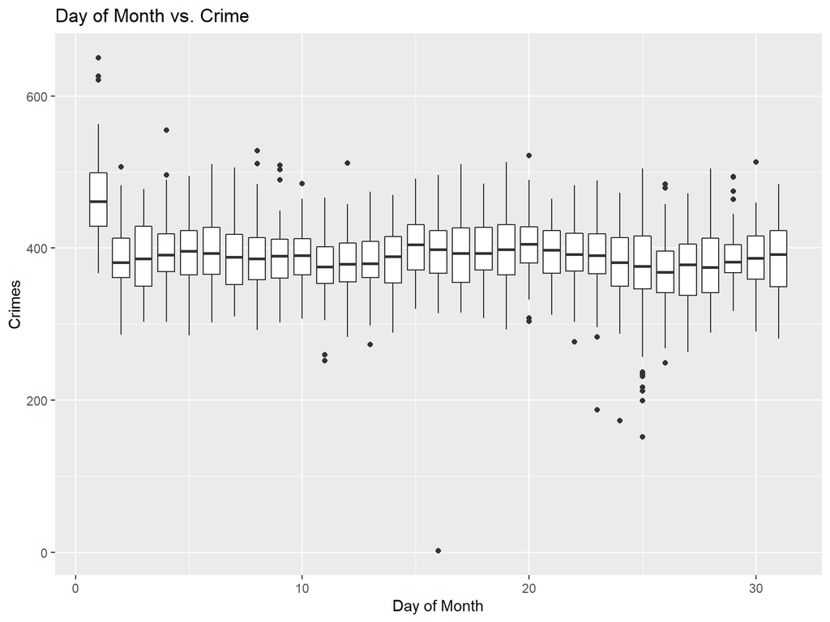

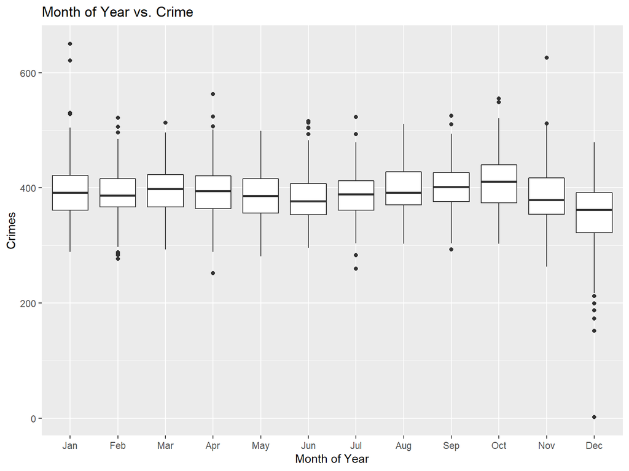

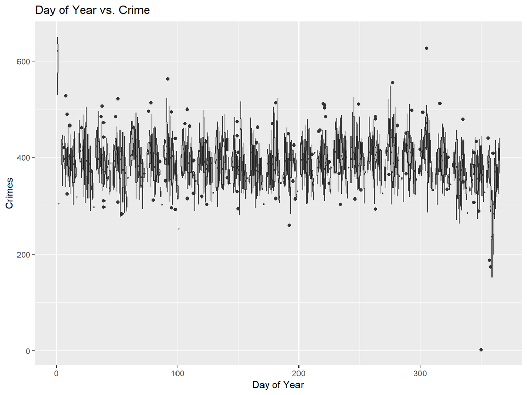

# Modeling

```
# Results
```

There does seem to be a slight incline, meaning crime is rising.

```
##   (Intercept)          date
## 370.985724915   0.001357645
```

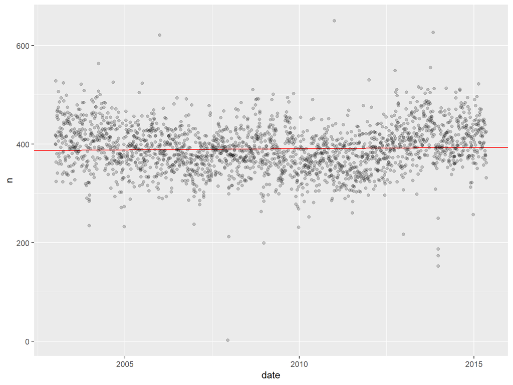

# Conclusion

```
# What I've Learned
```

```
# Machine Learning
```

Because the San Francisco crime dataset does not follow obvious statistical patterns, I think this data set is better suited for machine learning. The dataset on Kaggle is actually a competition dataset for machine learning. When looking through the notebooks people submitted, I noticed they all used the data as a training set to develop amazingly accurate classification models.

# References

wordcloud

https://github.com/lepennec/ggwordcloud

How to map San Francisco (Ken Steif)

http://urbanspatialanalysis.com/dataviz-tutorial-mapping-san-francisco-home-prices-using-r/

Kaggle dataset

https://www.kaggle.com/roshansharma/sanfranciso-crime-dataset

What is TREA?

https://www.kaggle.com/c/sf-crime/discussion/16289